# Homework 10

## Derek Anderson, Justin Dygert, Cameron Miller

### Question 1

```python
import numpy as np
import pandas as pd
import matplotlib.pyplot as plt
import seaborn as sns
sns.set()  #if you want to use seaborn themes with matplotlib functions
import statsmodels.api as sm

import warnings
warnings.filterwarnings('ignore')
```

1. Define your feature space and target variables. Split the data into test (30%) and train set (70%)

```python
df = pd.read_csv('bikeshare.csv')
df.drop('dteday', axis=1, inplace=True)
```

```python
rand_state = 1000

y = df['cnt']
X = df.drop('cnt', axis=1) # becareful inplace= False

from sklearn.model_selection import train_test_split
X_train, X_test, y_train, y_test = train_test_split(X, y, test_size=0.3, random_state=rand_state)
```

1. From sklearn.ensemble import the relevant function for RF regression. Do the followings:

```python
from sklearn.ensemble import RandomForestRegressor
```

2.1 Train the model with the default features. However use random_state=1000.

```python
RF_regression = RandomForestRegressor(random_state=1000)
RF_regression.fit(X_train, y_train)
```

```
RandomForestRegressor(random_state=1000)
```

2.2 Make predictions on the test set and save them as y_hat

```python
y_hat = RF_regression.predict(X_test)
```

2.3 Construct a data frame named df_predictions with 2 columns. y_test, and y_hat from previous part

```python
predictions = pd.DataFrame({ 'y_test':y_test,'y_hat':y_hat})
predictions.head()
```

|  | y_test | y_hat |
| --- | --- | --- |
| 4495 | 26 | 21.38 |
| 4418 | 47 | 64.21 |
| 7141 | 11 | 4.91 |
| 14765 | 205 | 199.84 |
| 16541 | 65 | 80.55 |

2.4 Visualize actual vs predicted counts in the test set using an scatterplot. Are you visually satisfied with the regression model?

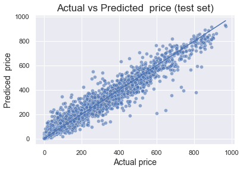

```python
sns.scatterplot(x=y_test, y=y_hat, alpha=0.6)
sns.lineplot(y_test, y_test)

plt.xlabel('Actual price', fontsize=14)
plt.ylabel('Prediced  price', fontsize=14)
plt.title('Actual vs Predicted  price (test set)', fontsize=17)
plt.show()
```

It appears to address the nature of the data so yes.

2.5 Report the R-squared and RMSE_test for the RFF regression model.

```python
np.round(RF_regression.score(X_test, y_test),4)
```

```
0.9488
```

1. Tuning hyperparameters: I specifically want you to use the following param_grid. my_param_grid = {'n_estimators':[100,200], 'max_features':['log2', 'auto'], 'max_depth':[10,None]} . Where you able to improve the model performance? Is random forest using a small tree or bushy tree? How do yo know?

Answer: We were not able to improve it - R^2 values went from 0.9488 to 0.9487. Random forest is using a bushy tree - we know this because the grid search before selected 'none' as the depth level. In addition to this, random forests are naturally bushy!

```python
from sklearn.model_selection import GridSearchCV

my_param_grid = {'n_estimators':[100,200], 'max_features':['log2', 'auto'], 'max_depth':[10,None]}
grid = GridSearchCV(estimator=RandomForestRegressor(random_state=rand_state),param_grid= my_param_grid, refit = True, verbose=2, cv=5 )
grid.fit(X_train,y_train)
```

[output not shown]

```
GridSearchCV(cv=5, estimator=RandomForestRegressor(random_state=1000),
             param_grid={'max_depth': [10, None],
                         'max_features': ['log2', 'auto'],
                         'n_estimators': [100, 200]},
             verbose=2)
```

```python
np.round(grid.score(X_test, y_test),4)
```

```
0.9487
```

1. Cross validation and OOB observations: estimate the R2 of the test set using both CV and OOB methods and compare the results.

```python
from sklearn.model_selection import cross_val_score
R2 = cross_val_score(estimator = RandomForestRegressor(n_estimators=200, random_state=rand_state), X = X_train, y = y_train, cv = 5 , scoring="r2" )

R2_CV = round(np.mean(R2),4)
R2_CV
```

```
0.7452
```

```python
RF_oob = RandomForestRegressor(n_estimators=200, random_state=rand_state, oob_score=True)
RF_oob.fit(X_train, y_train)

RF_oob.oob_score_
```

```
0.7541054980029842
```

1. Feature importance: Plot the feature importance graph and compare your top 5 important features with the top 5 most significant variables derived from a linear regression model. Can you name a variable which was important according to RF but not significant according to linear regression model? What's going on here?

```python
features = list(X_train.columns)
RF_Regressor = RandomForestRegressor(n_estimators = 200, random_state=rand_state)
RF_Regressor.fit(X_train, y_train)

importance = RF_Regressor.feature_importances_

FIM = pd.DataFrame({'Features': features, 'Feature_importance':importance})
FIM = FIM.sort_values(by=['Feature_importance'])
FIM
```

[output not shown]

```python
features = list(X_train.columns)
RF_Regressor = RandomForestRegressor(n_estimators = 200, random_state=rand_state)
RF_Regressor.fit(X_train, y_train)

importance = RF_Regressor.feature_importances_

FIM = pd.DataFrame({'Features': features, 'Feature_importance':importance})
FIM = FIM.sort_values(by=['Feature_importance'])
FIM
```

|  | Features | Feature_importance |
| --- | --- | --- |
| 4 | holiday | 0.002768 |
| 10 | windspeed | 0.011472 |
| 5 | weekday | 0.015552 |
| 2 | mnth | 0.016730 |
| 7 | weathersit | 0.018998 |
| 0 | season | 0.020617 |
| 9 | hum | 0.031922 |
| 6 | notbizday | 0.057761 |
| 1 | yr | 0.078752 |
| 8 | temp | 0.135310 |
| 3 | hr | 0.610118 |

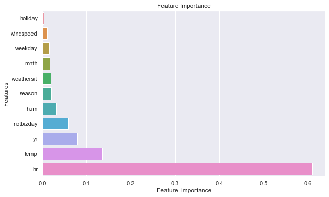

```python
plt.figure(figsize=(10,6))
plt.title('Feature Importance')
sns.barplot(y='Features', x='Feature_importance', data=FIM)
plt.show()
```

```python
import statsmodels.api as sm

X_test_wc = sm.add_constant(X_test)
X_train_wc = sm.add_constant(X_train)

model = sm.OLS(y_train,X_train_wc)
statsmodels_reg= model.fit()

statsmodels_reg.summary()
```

OLS Regression Results

| Dep. Variable: | cnt | R-squared: | 0.385 |
| --- | --- | --- | --- |
| Model: | OLS | Adj. R-squared: | 0.384 |
| Method: | Least Squares | F-statistic: | 691.2 |
| Date: | Mon, 11 Apr 2022 | Prob (F-statistic): | 0.00 |
| Time: | 15:53:50 | Log-Likelihood: | -77471. |
| No. Observations: | 12165 | AIC: | 1.550e+05 |
| Df Residuals: | 12153 | BIC: | 1.551e+05 |
| Df Model: | 11 |  |  |
| Covariance Type: | nonrobust |  |  |

|  | coef | std err | t | P>\|t\| | [0.025 | 0.975] |
| --- | --- | --- | --- | --- | --- | --- |
| const | 15.5033 | 5.664 | 2.737 | 0.006 | 4.401 | 26.606 |
| season | 19.3442 | 2.114 | 9.149 | 0.000 | 15.199 | 23.489 |
| yr | 80.3554 | 2.576 | 31.191 | 0.000 | 75.306 | 85.405 |
| mnth | 0.0406 | 0.658 | 0.062 | 0.951 | -1.249 | 1.330 |
| hr | 7.4540 | 0.196 | 38.014 | 0.000 | 7.070 | 7.838 |
| holiday | -23.9886 | 7.879 | -3.045 | 0.002 | -39.432 | -8.545 |
| weekday | 1.7031 | 0.643 | 2.649 | 0.008 | 0.443 | 2.964 |
| notbizday | -2.4919 | 2.857 | -0.872 | 0.383 | -8.093 | 3.109 |
| weathersit | -3.5995 | 2.274 | -1.583 | 0.113 | -8.057 | 0.858 |
| temp | 54.3312 | 1.378 | 39.424 | 0.000 | 51.630 | 57.033 |
| hum | -37.7405 | 1.578 | -23.919 | 0.000 | -40.833 | -34.648 |
| windspeed | 4.7366 | 1.362 | 3.477 | 0.001 | 2.066 | 7.407 |

| Omnibus: | 2452.232 | Durbin-Watson: | 2.023 |
| --- | --- | --- | --- |
| Prob(Omnibus): | 0.000 | Jarque-Bera (JB): | 4830.463 |
| Skew: | 1.219 | Prob(JB): | 0.00 |
| Kurtosis: | 4.893 | Cond. No. | 94.4 |

Notes:  
[1] Standard Errors assume that the covariance matrix of the errors is correctly specified.

Notbizday was one of the more important variables, but had a p-value of .383 in linear regression, which means its not significant. This is because trees are looking at what variables have a significant impact on splitting trees. Linear regression looks at significant relationship between the target and the specific feature.

### Question 2

1. Define a binary target variable overload. Overload=1 if cnt>500 and 0 otherwise. What are the proportions of overload vs non-overload in your data set? Is the target variable balanced or imbalanced?

```python
df['overload'] = np.where(df['cnt'] > 500, 1, 0)
df.drop('cnt', axis=1, inplace=True)

pd.crosstab(df['overload'],df['overload'], normalize='all')*100
```

| overload | 0 | 1 |
| --- | --- | --- |
| 0 | 92.640543 | 0.000000 |
| 1 | 0.000000 | 7.359457 |

92% of the data is non overloaded, with about 7% overload. This is highly imbalanced.

1. Along with the target variable, define your feature space (X) and split the data into test (30%) and train set (70%)

```python
y = df['overload']
X = df.drop(['overload'], axis=1) # becareful inplace= False

from sklearn.model_selection import train_test_split
X_train, X_test, y_train, y_test = train_test_split(X, y, test_size=0.3, random_state=rand_state)
```

1. From sklearn.ensemble import the relevant function for RF classification. Do the followings:

```python
from sklearn.ensemble import RandomForestClassifier
```

3.1 Train the RF classification model using its default parameters. However use random_state=1000.

```python
RF_classifier = RandomForestClassifier(random_state=rand_state)
RF_classifier.fit(X_train, y_train)
```

```
RandomForestClassifier(random_state=1000)
```

3.2 Generate the predicted probabilities and predicted classifications and save them as y_hat_probs, y_hat respectively.

```python
y_hat      = RF_classifier.predict(X_test)
y_hat_probs = RF_classifier.predict_proba(X_test)[:,1]
```

3.3 Plot the histogram of y_hat_probs? Explain what you see? Is there a probability threshold at which the model always predict negative or positive?

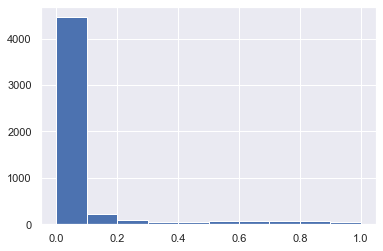

```python
plt.hist(y_hat_probs)
plt.show()
```

This is a very right skewed histogram. Most of the probabilities are less than .1, this means most of the observations have a low probability of being overload. It looks like the only threshold to always predict negative or positive is 0 or 1.

3.4 Use the built-in classification report function from sklearn. Report the Accuracy, precision, recall and f1 score along with the confusion matrix. Interpret all of these statistics. Do you trust the accuracy of the model? why?

```python
from sklearn.metrics import accuracy_score, recall_score, precision_score, f1_score
from sklearn.metrics import confusion_matrix, classification_report, roc_curve, roc_auc_score

print(confusion_matrix(y_test, y_hat))
print(classification_report(y_test, y_hat))
```

```
[[4784   35]
 [ 113  282]]
              precision    recall  f1-score   support

           0       0.98      0.99      0.98      4819
           1       0.89      0.71      0.79       395

    accuracy                           0.97      5214
   macro avg       0.93      0.85      0.89      5214
weighted avg       0.97      0.97      0.97      5214
```

The accuracy is .97. This reports overall how well the model is doing. This accuracy is very good. Precision is the quality of positive predicitons in our model. Our model has a precision of .89, which means its quality is quite good. Recall measures how well our model predicts positives that are actually positive. For our model we have a value of .71, which means its alright. F1 uses both recall and precision. Our f1 score is .79, which is pretty good. We dont trust the accuracy that much. There are quite a lot of false negatives for such an imbalanced data set.

1. Tuning hyperparameters: I specifically want you to use the following param_grid. my_param_grid = {'n_estimators':[100,200], 'criterion':['gini','entropy'], 'max_features':['log2', 'auto'], 'max_depth':[10,None]} . Where you able to improve the model performance? Is random forest using a small tree or bushy tree? How do yo know?

```python
my_param_grid = {'n_estimators':[100,200], 'criterion':['gini','entropy'],  'max_features':['log2', 'auto'], 'max_depth':[10,None]}

grid = GridSearchCV(estimator=RandomForestClassifier(random_state=rand_state),param_grid= my_param_grid, refit = True, verbose=2, cv=5 )
grid.fit(X_train,y_train)
```

[output not shown]

[output cut: 26 more lines]

[output not shown]

```
GridSearchCV(cv=5, estimator=RandomForestClassifier(random_state=1000),
             param_grid={'criterion': ['gini', 'entropy'],
                         'max_depth': [10, None],
                         'max_features': ['log2', 'auto'],
                         'n_estimators': [100, 200]},
             verbose=2)
```

```python
y_hat_optimized = grid.predict(X_test)

print(confusion_matrix(y_test, y_hat_optimized))
print(classification_report(y_test, y_hat_optimized))
```

```
[[4782   37]
 [ 100  295]]
              precision    recall  f1-score   support

           0       0.98      0.99      0.99      4819
           1       0.89      0.75      0.81       395

    accuracy                           0.97      5214
   macro avg       0.93      0.87      0.90      5214
weighted avg       0.97      0.97      0.97      5214
```

The accuracy stayed the same. The model chose None as the depth, so it grew full trees which are bushy trees. Also, this high accuracy is probably due to overfitting, which happens with busy trees.

1. Cross validation and OOB observations: estimate the accuracy of the test set using both CV and OOB methods and compare the results.

```python
grid.best_estimator_
```

```
RandomForestClassifier(criterion='entropy', max_features='log2',
                       random_state=1000)
```

```python
RF_acc = cross_val_score(estimator = RandomForestClassifier(criterion='entropy', max_features='log2', random_state=rand_state), X = X_train, y = y_train, cv = 5 , scoring="accuracy" )

RF_acc = round(np.mean(RF_acc),4)
RF_acc
```

```
0.9739
```

```python
RF_acc_oob = RandomForestClassifier(criterion='entropy', max_features='log2', random_state=rand_state, oob_score=True)
RF_acc_oob.fit(X_train, y_train)

RF_acc_oob.oob_score_
```

```
0.9719687628442253
```

The accuracies are quite similar, the oob is slightly lower.

1. Dealing with imbalanced data: Use the balanced version of RF classifier and save the predictions as y_hat_balanced. Report the precision, recall and f1 score for the balanced RF versus what you found in part 3.4. What happened to recall? does that make sense?

```python
RF_balanced = RandomForestClassifier(random_state=1000, criterion='entropy', max_features='log2', class_weight='balanced_subsample')

y_hat_balanced = RF_balanced.fit(X_train, y_train).predict(X_test)

print(confusion_matrix(y_test, y_hat_balanced))
print(classification_report(y_test, y_hat_balanced))
```

```
[[4788   31]
 [ 103  292]]
              precision    recall  f1-score   support

           0       0.98      0.99      0.99      4819
           1       0.90      0.74      0.81       395

    accuracy                           0.97      5214
   macro avg       0.94      0.87      0.90      5214
weighted avg       0.97      0.97      0.97      5214
```

1. Plot the ROC curve for the balanced RF and report the AUC. Can you trust this number now? why?

```
No Skill     : ROC AUC=0.500
Random Forest: ROC AUC=0.985
```

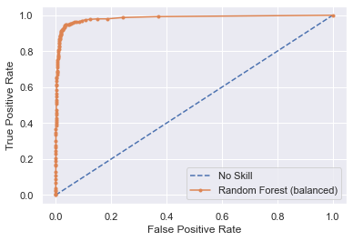

```python
from sklearn.metrics import roc_curve, roc_auc_score

ns_probs = [0 for i in range(len(y_test))]
lr_probs = RF_balanced.predict_proba(X_test)[:,1]
# calculating scores for no skill and logistic regression
ns_auc = roc_auc_score(y_test, ns_probs)
lr_auc = roc_auc_score(y_test, lr_probs)
print('No Skill     : ROC AUC=%.3f' % (ns_auc))
print('Random Forest: ROC AUC=%.3f' % (lr_auc))

# calculate roc curves
ns_fpr, ns_tpr, _ = roc_curve(y_test, ns_probs)
lr_fpr, lr_tpr, _ = roc_curve(y_test, lr_probs)
# plot the roc curve for the model
plt.plot(ns_fpr, ns_tpr, linestyle='--', label='No Skill')
plt.plot(lr_fpr, lr_tpr, marker='.', label='Random Forest (balanced)')
# axis labels
plt.xlabel('False Positive Rate')
plt.ylabel('True Positive Rate')
# show the legend
plt.legend()
# show the plot
plt.show()
```

Yes. This does far better than a no skill model.

1. Feature importance: Plot the feature importance graph and report the top 5 important features. Is your finding consistent with common sense?

```python
importance = RF_balanced.feature_importances_

FIM = pd.DataFrame({'Features': features , 'Feature_importance':importance})
FIM = FIM.sort_values(by=['Feature_importance'])
FIM
```

|  | Features | Feature_importance |
| --- | --- | --- |
| 4 | holiday | 0.004807 |
| 7 | weathersit | 0.016157 |
| 0 | season | 0.032417 |
| 6 | notbizday | 0.044106 |
| 5 | weekday | 0.044243 |
| 10 | windspeed | 0.045088 |
| 2 | mnth | 0.054123 |
| 9 | hum | 0.092329 |
| 1 | yr | 0.121674 |
| 8 | temp | 0.125502 |
| 3 | hr | 0.419556 |

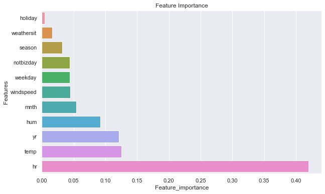

```python
plt.figure(figsize=(10,6))
plt.title('Feature Importance')
sns.barplot(y='Features', x='Feature_importance', data=FIM)
plt.show()
```

The 5 most important variables are hr, temp, yr, hum, and month. This makes sense, people usually ride bikes only during the day, and likely different times of day are busier than others. Temp also makes sense, people are more willing to ride a bike in warmer weather. Humidity and month also are important for similar reason, warmer weather months likely recieve more activity than the colder months.